# Lab 2 - Aprendizaje No Supervisado

## 1.7 Evaluación con método de la silueta

```
##   cluster size ave.sil.width
## 1       1 9225          0.23
## 2       2  892          0.05
## 3       3  282          0.31
## 4       4 9322          0.55
```

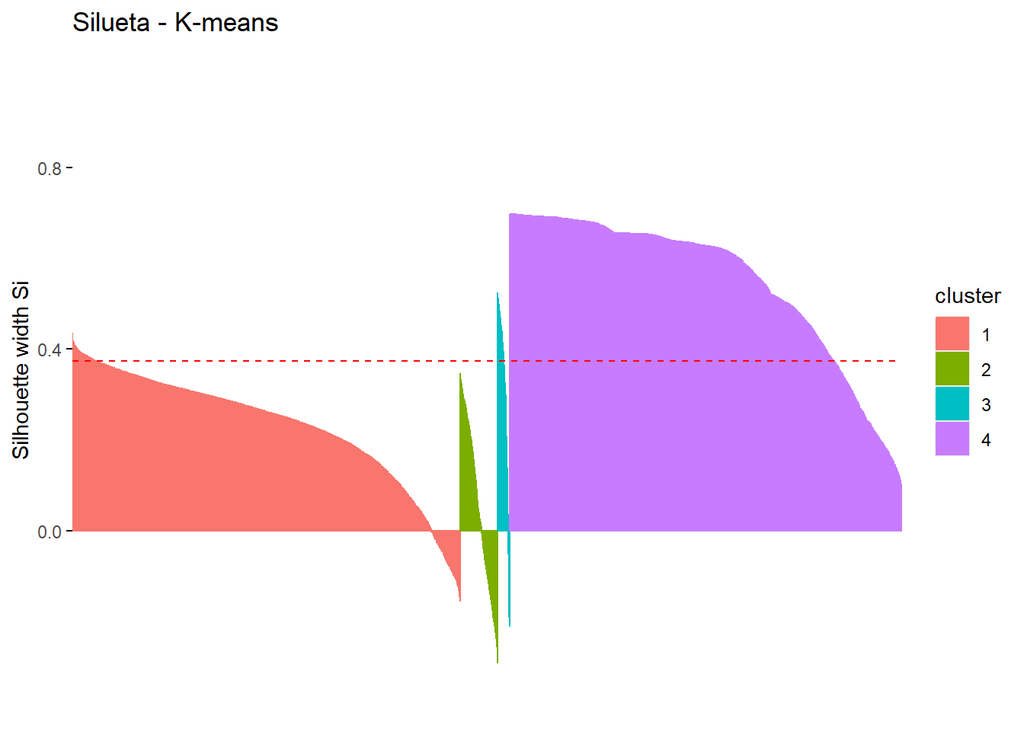

```r
# Silueta K-means
sil_kmeans <- silhouette(kmeans_result$cluster, dist(scaled_data))
fviz_silhouette(sil_kmeans) +
  labs(title = "Silueta - K-means")
```

```
##   cluster  size ave.sil.width
## 1       1 19701          0.81
## 2       2     1          0.00
## 3       3    17          0.16
## 4       4     2          0.50
```

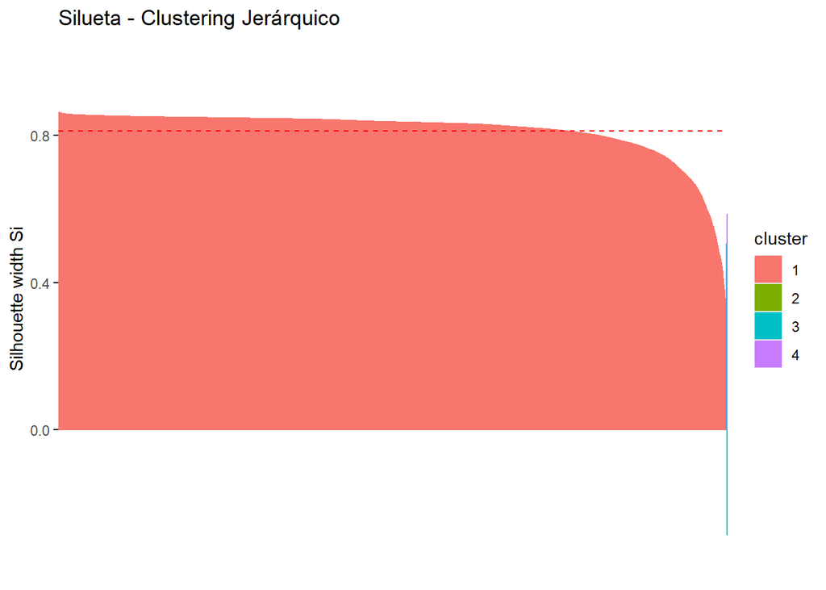

```r
# Silueta Jerárquico
sil_hc <- silhouette(hc_clusters, dist(scaled_data))
fviz_silhouette(sil_hc) +
  labs(title = "Silueta - Clustering Jerárquico")
```

```r
mean_sil_kmeans <- mean(sil_kmeans[,3])
mean_sil_hc     <- mean(sil_hc[,3])

cat("Silueta promedio K-means:", round(mean_sil_kmeans, 4), "\n")
```

```
## Silueta promedio K-means: 0.374
```

```r
cat("Silueta promedio Jerárquico:", round(mean_sil_hc, 4), "\n")
```

```
## Silueta promedio Jerárquico: 0.8113
```

### Interpretación de la silueta

- **K-means** obtuvo una silueta promedio de aproximadamente **0.37**, indicando una separación moderada entre grupos.
- **Clustering Jerárquico** obtuvo una silueta promedio más alta (~0.81), pero generó un grupo extremadamente dominante con la casi totalidad de las observaciones y clusters de una sola película, lo cual hace que el indicador sea artificialmente alto y el agrupamiento no sea útil para interpretación práctica.

K-means, aunque con silueta menor, genera grupos más equilibrados y accionables.  
**Se selecciona K-means para el análisis final.**

## 1.8 Interpretación de los grupos (K-means)

```r
movies_clustered <- as.data.frame(numeric_vars)
movies_clustered$cluster_kmeans <- kmeans_result$cluster

cat("Tamaño de cada cluster:\n")
```

```
## Tamaño de cada cluster:
```

```r
table(movies_clustered$cluster_kmeans)
```

```
##
##    1    2    3    4
## 9225  892  282 9322
```

```r
medias_cluster <- movies_clustered %>%
  group_by(cluster_kmeans) %>%
  summarise(across(everything(), mean, .names = "{.col}"))

print(medias_cluster)
```

```
## # A tibble: 4 × 13
##   cluster_kmeans popularity     budget    revenue runtime voteAvg voteCount
##            <int>      <dbl>      <dbl>      <dbl>   <dbl>   <dbl>     <dbl>
## 1              1      37.2   10277804.  23112887.   101.    6.43     763.
## 2              2     163.   103110290. 401367712.   121.    6.90    7133.
## 3              3      47.2     262218.   2577397.    85.5   6.28      73.4
## 4              4       1.44      6794.      3963.    26.1   0.864      1.90
## # ℹ 6 more variables: genresAmount <dbl>, productionCoAmount <dbl>,
## #   productionCountriesAmount <dbl>, actorsAmount <dbl>, castWomenAmount <dbl>,
## #   castMenAmount <dbl>
```

### Interpretación detallada de los grupos

#### 🔵 Cluster 1 – Producciones comerciales medias

- Presupuesto promedio ≈ 10 millones | Revenue ≈ 23 millones
- Popularidad ≈ 37 | VoteAvg ≈ 6.4 | Runtime ≈ 101 minutos

Representa películas comerciales estándar con presupuesto moderado y desempeño estable en taquilla. Son producciones típicas de mercado con buena aceptación del público.

#### 🔴 Cluster 2 – Grandes producciones (Blockbusters)

- Presupuesto ≈ 103 millones | Revenue ≈ 401 millones
- Popularidad ≈ 163 | VoteCount ≈ 7,133 | Runtime ≈ 121 minutos

Corresponde claramente a películas tipo blockbuster: alta inversión, alta visibilidad y retorno multiplicado. Representan el segmento más estratégico y rentable del mercado.

#### 🟢 Cluster 3 – Cine independiente / Bajo presupuesto

- Presupuesto ≈ 262 mil | Revenue ≈ 2.5 millones
- Popularidad ≈ 47 | VoteAvg ≈ 6.28 | VoteCount bajo

Producciones de bajo presupuesto con buena recepción crítica. Probablemente cine independiente o de nicho con audiencias fieles pero reducidas.

#### 🟣 Cluster 4 – Producciones marginales / Cortometrajes

- Presupuesto ≈ 6,794 | Revenue ≈ 3,963
- Popularidad ≈ 1.44 | VoteAvg ≈ 0.86 | Runtime ≈ 26 minutos

Agrupa producciones de muy bajo impacto: cortometrajes, proyectos experimentales o producciones no comerciales sin distribución masiva.

### Conclusión del Clustering

El análisis identificó cuatro segmentos diferenciados del mercado cinematográfico:

1. **Blockbusters** – Alta inversión, altísimo retorno y popularidad masiva.
2. **Producciones medianas** – Mercado mainstream con retorno proporcional.
3. **Cine independiente** – Bajo presupuesto, buena crítica, nicho fiel.
4. **Producciones marginales** – Impacto mínimo, probablemente no comerciales.

Esta segmentación puede orientar a CineVision Studios a definir en cuál segmento desea posicionarse y qué tipo de inversión maximiza su retorno esperado.

# 2. Análisis de Componentes Principales (PCA)

```r
library(psych)
library(REdaS)
library(corrplot)
library(factoextra)
```

## 2.1 Variables categóricas y viabilidad de inclusión en PCA

El PCA es una técnica basada en varianza y correlaciones lineales entre variables **numéricas continuas**. Las variables categóricas del dataset (originalLanguage, genres, productionCompany, director, actors, etc.) no pueden incluirse directamente en un PCA estándar.

Una alternativa sería aplicar **One-Hot Encoding** para convertirlas en variables dummy (0/1). Sin embargo, dado que variables como `genres`, `actors` o `productionCompany` tienen decenas o cientos de categorías únicas, esto generaría una matriz muy dispersa con miles de columnas adicionales, la mayoría con correlaciones muy bajas entre sí. Esto no solo incrementa la dimensionalidad en lugar de reducirla, sino que también viola el supuesto de correlación continua necesario para PCA. **Por tanto, no vale la pena incluir las variables categóricas en este PCA.**

Se procede con las 12 variables numéricas del dataset.